# Reliability and Multi-Group CFA analysis

Anne-Flore Cabouat adapt Eliane

## Librairies

```r
library(dplyr)
library(knitr) #RStudio
library(png) #output png
```

```r
library(corrplot) #plot correlation matrix
library(misty) #Little's test for MCAR
#library(mice)
library(mifa) # MICE for missing data handling
library(psych) # for EFA
library(RColorBrewer) #for corr matrix
library(lavaan) # for cfa
```

## Functions

```r
make_corrM <- function(d = NULL, order = NULL, ...) {

  #if (is.null(d)) {
  #  if (exists("r_mat")) return(r_mat)
  #  return(NULL)
  #}


  print("corr M linha 55")

   # Mantain the original column names
  d <- as.data.frame(d)

  # 2. Remove items with 0 variance
  valid_cols <- sapply(d, function(col) length(unique(na.omit(col))) > 1)
  d_clean <- d[, valid_cols, drop = FALSE]


  if (ncol(d_clean) < 2) return(NULL)



  # 3. Convert to orederd factors and mantain the column names
  orig_names <- colnames(d_clean)
  d_ordered <- as.data.frame(lapply(d_clean, ordered), check.names = FALSE)
  colnames(d_ordered) <- orig_names




  # 4. Calculate the polychoric correlation with pairwise deletion
  het <- tryCatch({
    polycor::hetcor(
      d_ordered,
      use = "pairwise.complete.obs",
      std.err = FALSE,
      ML = FALSE
    )
  }, error = function(e) NULL)




  if (is.null(het)) return(NULL)

  corr_matrix <- het$correlations

  # Original names in columns and rows of the matrix
  dimnames(corr_matrix) <- list(orig_names, orig_names)

  # 5. Reordering opcional
  if (!is.null(order) && length(order) > 0) {
    valid_order <- intersect(order, colnames(corr_matrix))
    if (length(valid_order) > 1) {
      corr_matrix <- corr_matrix[valid_order, valid_order, drop = FALSE]
    }
  }

  return(corr_matrix)
}

# Applicability of EFA

## Bartlett test of sphericity - from TH
bartlettTest <- function(corrMatrix,data){
  bart <- cortest.bartlett(corrMatrix, n = nrow(data))
  if(bart[2]>0.05) cat("WARNING the p value is above 0.05") else cat("The p value is below 0.05. We are good to continue.")
  cat("\n\n")
  print(bart)
  return(bart)
}

##KMO to complement Bartlett - from TH
KMOTest <- function(corrMatrix){
  kmo <- KMO(corrMatrix)
  cat(paste("The overall measure of sampling adequacy is: ",kmo[1]))
  cat("\n\n")
  if(kmo[1]<.7) cat("WARNING the sampling adequacy has dropped below 0.7") else cat("The sampling adequacy is above 0.7. We are generally good.")
  cat("\n\n")
  return(kmo)
}

# Missing values

missingTest <- function(na_percent, mcar_pvalue){
  if (na_percent<5 & mcar_pvalue<=.05){
      cat("Data is MCAR and less than 5% missing data, which is negligible. We are good to continue.")
  } else if (na_percent<5 & mcar_pvalue>.05){
      cat("Data is NOT MCAR but less than 5% missing data, which is negligible. We are good to continue.")
  } else if(na_percent>=5 & mcar_pvalue>.05) {
      cat("WARNING missing data is not negligible (> 5%) AND missing data is NOT MCAR. Further investigation is needed.")
    }else if (na_percent>=5 & na_percent<40 & mcar_pvalue<=.05){
      cat("Data is MCAR but more than 5% missing data. Use imputation / likelihood methods.")
    }  else {
      cat("40% or more missing data and / or something is wrong.")
    }}


# Parallel analysis for each group

parallelAnalysis <- function(corrMatrix, observations = nrow(the_data), file_suffix){
  pdf(paste(paste(file.path(output_dir, "generatedPlots-CFA/ScreePlot-"),file_suffix,sep=""),'.pdf'), width=8, height=4)
  parallel <- fa.parallel(corrMatrix, n.obs=observations, fa="fa", n.iter=100, main="Scree plots with parallel analysis", error.bars = TRUE)
  print(parallel)
  dev.off()
  cat("\n\n")
}

stimulus_data_test <- function(the_data, the_letter){
  ## Here wwe run test on the data
  ### Shapiro Wilk’s test (P-values < 0.05 indicate not normal)
  cat(paste("\n=================\n NORMALITY in", the_letter, "\n"))

  cat(paste("\n #### Shapiro in", the_letter, "\n"))
  mapply(shapiro.test, the_data)

  ### Multivariate normality
  # To say the data are multivariate normal:
  # • z-kurtosis < 5 (Bentler, 2006) and the P-value should be ≥ 0.05.
  # • the plot should also form a straight line (Arifin, 2015).

  cat(paste("\n #### Multivariate normality in", the_letter, "\n"))
  mardia(the_data)

  cat(paste("\n=================\n MISSING DATA IN in", the_letter, "\n"))
  ### Missing data

  if (anyNA(the_data)) {
  cat("#### Little's test for MCAR\n")
  #test MCAR
  MCAR <- na.test(the_data)
  mcar_p <- MCAR[["result"]][["pval"]]

  cat("\n#### Amount of missing data\n")
  nb_obs <- nrow(the_data)*ncol(the_data)
  na_amount <- sum(is.na(the_data))/nb_obs*100
  cat(paste(as.numeric(na_amount)), "% of data is missing\n\n")

  missingTest(na_amount, mcar_p)
  } else {
  cat("No missing values found in the_data.\n")
  }


### Multiple Imputation for missing values
  cat(paste("\n Multiple Imputation for missing values in", the_letter, "\n"))

  print("4 corr M sem parametro")
  #corr_M <- make_corrM(the_data, nb_fa = 4) PREVIS
  corr_M <- make_corrM()


  cat(paste("\n=================\n FACTORABILITY in", the_letter, "\n"))

  ####  Bartlett’s test of sphericity
  # An objective test of the factorability of the correlation matrix is Bartlett’s (1954) test of sphericity, which statistically tests the hypothesis that the correlation matrix contains ones on the diagonal and zeros on the off-diagonals. Hence, that it was generated by random data. This test should produce a statistically significant chi-square value to justify the application of EFA.
  # If the p-value from Bartlett’s Test of Sphericity is lower than our chosen significance level (common choices are 0.10, 0.05, and 0.01), then our dataset is suitable for a data reduction technique.
  cat(paste("\n #### Bartlett in", the_letter, "\n"))
  bartlettTest(corr_M, the_data)

  ####  KMO
  # Large sample sizes make the Bartlett test sensitive to even trivial deviations from randomness, so its results should be supplemented with a measure of sampling adequacy. The Kaiser-Meyer-Olkin (KMO; Kaiser, 1974) measure of sampling adequacy is the ratio of correlations and partial correlations that reflects the extent to which correlations are a function of the variance shared across all variables rather than the variance shared by particular pairs of variables. KMO values range from 0.00 to 1.00 and can be computed for the total correlation matrix as well as for each measured variable.
  # - KMO values ≥.70 are desired
  # - KMO values ≤.50 are generally considered unacceptable
  cat(paste("\n #### KMO in", the_letter, "\n"))
  KMOTest(corr_M)



  parallelAnalysis(corr_M, observations=nb_obs, "All")

}

fitMeasures_output <- function(modelFit, model_name) {
  print(fitMeasures(modelFit, c("chisq", "df", "pvalue", "cfi", "rmsea"),
                  output = "text"), add.h0 = TRUE)

  fit_Indices <- fitMeasures(modelFit, output = "matrix")
  colnames(fit_Indices)[1] <- c(model_name)
  write.csv(fit_Indices,file= file.path(output_dir, (paste("generatedData-CFA/fit_indices-", model_name, ".csv", sep=""))))


  #file = file.path(pasta_saida, nome_arquivo)


  cat("\nDETAILS\n=================\n")
  print(fit_Indices)

  # cat("\n RMSEA - \n")
  # this_RMSEAIndices <- fit_Indices[c("rmsea","rmsea.pvalue","rmsea.ci.lower","rmsea.ci.upper","rmsea.ci.level")]
  # print(this_RMSEAIndices)
  #
  # cat("\n SRMR \n")
  # this_SRMRIndices <- fit_Indices[c("srmr")]
  # print(this_SRMRIndices)
  #
  # cat("\n Comparative Fit Index \n")
  # this_CFIIndices <- fit_Indices[c("cfi")]
  # print(this_CFIIndices)
  #
  # cat("\n Chi-square \n")
  # this_ChiSquareIndices <- fit_Indices[c("chisq","df","pvalue")]
  # print(this_ChiSquareIndices)

}

select_all_variables <- function (dataset, col_list) {
  dataset %>% select(all_of(unlist(col_list)))
}
```

## Multigroup CFA

https://lavaan.ugent.be/tutorial/groups.html

```r
#we retrieve our model from EFA conducted on all data

this_model <- "Tested_model" #model used in the validation survey

#UX_factors <- list(
#  visualization = list('P106','P089','P098','P097', 'P022A','P067'),
#  cognitive = list('P064', 'P301', 'P060', 'P027'),
#  intuitiveness = list('P088', 'P026', 'P4026A')
#)


UX_factors <- list(
  visualization = list('VisFaithful', 'VisSimpleUnderstand', 'VisAppropriate', 'VisSysRetrieveInfo', 'VisRemember', 'VisTrialError'),
  cognitive = list('CogSysThinkDeep', 'CogSysUseful', 'CogSysEnjoy', 'CogTaskComplete'),
  intuitiveness = list('IntSysSimpleUnderstand', 'IntSysEasyStart', 'IntAnalysisConfigure')
)


# Create a vector of column names to keep for the model with selected items
columns_to_keep <- unlist(UX_factors)

# Function to convert a factor list to the required string format
factor_to_string <- function(factor_name, factor_list) {
  paste(factor_name, " =~ ", paste(factor_list, collapse = " + "))
}
```

## Load data

```r
stimuli_letters <- list("Tableau","JMP", "Excel", "Data Studio","Power BI")

grp_data <- read.csv(paste("../Data/multigroup_ratings.csv"), encoding="UTF-8")
data <- subset(grp_data, select = -c(stimulus))

# and make directories if needed



generated_data_dir  <- file.path(output_dir, "generatedData-CFA")
generated_plots_dir  <- file.path(output_dir, "generatedPlots-CFA")

# Cria as pastas caso não existam
if (!dir.exists(generated_data_dir)) {
  dir.create(generated_data_dir, recursive = TRUE)
}

if (!dir.exists(generated_plots_dir)) {
  dir.create(generated_plots_dir, recursive = TRUE)
}
```

## Descriptive statistics - Check minimum/maximum values per item, and screen for missing values

```r
cat("\n\n==========================================\n
    ==========================================\n
    ==========================================\n")
cat("\n\n OVERVIEW \n\n")
```

```
##
##
##  OVERVIEW
```

```r
cat("==========================================\n
    ==========================================\n
    ==========================================\n\n")
describe(data)
```

```
##                        vars   n         mean           sd       median
## id                        1 226 4.421700e+02       390.12        328.5
## seed                      2 226 1.096802e+09 598607530.40 1089913579.0
## IntSysEasyStart           3 226 5.470000e+00         1.25          6.0
## IntSysSimpleUnderstand    4 226 5.630000e+00         1.14          6.0
## IntAnalysisConfigure      5 226 5.480000e+00         1.18          6.0
## VisRemember               6 226 5.980000e+00         0.83          6.0
## VisTrialError             7 225 5.550000e+00         1.05          6.0
## VisSimpleUnderstand       8 226 6.080000e+00         0.83          6.0
## VisSysRetrieveInfo        9 226 6.050000e+00         0.81          6.0
## VisAppropriate           10 226 6.200000e+00         0.63          6.0
## VisFaithful              11 224 6.290000e+00         0.62          6.0
## CogTaskComplete          12 225 6.140000e+00         0.78          6.0
## CogSysEnjoy              13 226 5.950000e+00         0.96          6.0
## CogSysThinkDeep          14 225 5.760000e+00         1.07          6.0
## CogSysUseful             15 226 6.420000e+00         0.65          7.0
##                             trimmed          mad     min        max      range
## id                     4.117100e+02       406.23       7       1135       1128
## seed                   1.101878e+09 743566611.48 3864603 2144449168 2140584565
## IntSysEasyStart        5.620000e+00         1.48       2          7          5
## IntSysSimpleUnderstand 5.770000e+00         1.48       2          7          5
## IntAnalysisConfigure   5.610000e+00         1.48       2          7          5
## VisRemember            6.040000e+00         1.48       4          7          3
## VisTrialError          5.620000e+00         1.48       3          7          4
## VisSimpleUnderstand    6.150000e+00         1.48       4          7          3
## VisSysRetrieveInfo     6.110000e+00         1.48       4          7          3
## VisAppropriate         6.250000e+00         0.00       5          7          2
## VisFaithful            6.350000e+00         0.00       5          7          2
## CogTaskComplete        6.210000e+00         1.48       4          7          3
## CogSysEnjoy            6.060000e+00         1.48       3          7          4
## CogSysThinkDeep        5.870000e+00         1.48       3          7          4
## CogSysUseful           6.520000e+00         0.00       5          7          2
##                         skew kurtosis          se
## id                      0.55    -1.20       25.95
## seed                   -0.06    -1.09 39818780.61
## IntSysEasyStart        -0.97     0.44        0.08
## IntSysSimpleUnderstand -1.23     1.53        0.08
## IntAnalysisConfigure   -1.03     0.79        0.08
## VisRemember            -0.52    -0.28        0.06
## VisTrialError          -0.49    -0.22        0.07
## VisSimpleUnderstand    -0.61    -0.22        0.05
## VisSysRetrieveInfo     -0.49    -0.43        0.05
## VisAppropriate         -0.18    -0.61        0.04
## VisFaithful            -0.29    -0.67        0.04
## CogTaskComplete        -0.63    -0.06        0.05
## CogSysEnjoy            -1.00     1.03        0.06
## CogSysThinkDeep        -0.70    -0.09        0.07
## CogSysUseful           -0.69    -0.58        0.04
```

```r
response.frequencies(data)
```

```
##                                 2          3          4          5         6
## IntSysEasyStart        0.02654867 0.08849558 0.04424779 0.25221239 0.4026549
## IntSysSimpleUnderstand 0.02654867 0.03982301 0.06637168 0.19911504 0.4823009
## IntAnalysisConfigure   0.02654867 0.05752212 0.08407080 0.22566372 0.4557522
## VisRemember            0.00000000 0.00000000 0.05309735 0.19469027 0.4690265
## VisTrialError          0.00000000 0.04444444 0.10222222 0.29777778 0.3688889
## VisSimpleUnderstand    0.00000000 0.00000000 0.04424779 0.17256637 0.4469027
## VisSysRetrieveInfo     0.00000000 0.00000000 0.03539823 0.19911504 0.4424779
## VisAppropriate         0.00000000 0.00000000 0.00000000 0.11504425 0.5663717
## VisFaithful            0.00000000 0.00000000 0.00000000 0.08928571 0.5312500
## CogTaskComplete        0.00000000 0.00000000 0.03111111 0.15111111 0.4666667
## CogSysEnjoy            0.00000000 0.03097345 0.03982301 0.18141593 0.4469027
## CogSysThinkDeep        0.00000000 0.04000000 0.08444444 0.23111111 0.3688889
## CogSysUseful           0.00000000 0.00000000 0.00000000 0.08849558 0.3982301
##                                7        miss
## IntSysEasyStart        0.1858407 0.000000000
## IntSysSimpleUnderstand 0.1858407 0.000000000
## IntAnalysisConfigure   0.1504425 0.000000000
## VisRemember            0.2831858 0.000000000
## VisTrialError          0.1866667 0.004424779
## VisSimpleUnderstand    0.3362832 0.000000000
## VisSysRetrieveInfo     0.3230088 0.000000000
## VisAppropriate         0.3185841 0.000000000
## VisFaithful            0.3794643 0.008849558
## CogTaskComplete        0.3511111 0.004424779
## CogSysEnjoy            0.3008850 0.000000000
## CogSysThinkDeep        0.2755556 0.004424779
## CogSysUseful           0.5132743 0.000000000
```

```r
nb_obs <- nrow(data)
cat("\n Sample size:")
```

```
##
##  Sample size:
```

```r
print(nb_obs)
```

```
## [1] 226
```

```r
cat("\n\n==========================================\n")
cat("==========================================\n")
cat("==========================================\n")
cat("\n \n CORRELATIONS \n \n")
```

```
##
##
##  CORRELATIONS
##
```

```r
cat("==========================================\n")
cat("==========================================\n")
cat("==========================================\n\n")
colnames(columns_to_keep)
```

```r
data_reduced_factors <- data %>%
  dplyr::select(dplyr::all_of(unname(columns_to_keep)))


# Correlation Matrix with selected items
#data_reduced_factors <- data %>% dplyr::select(dplyr::all_of(columns_to_keep))

print("1 - antes make_corrM")
```

```
## [1] "1 - antes make_corrM"
```

```r
colnames(data_reduced_factors)
```

```
##  [1] "VisFaithful"            "VisSimpleUnderstand"    "VisAppropriate"
##  [4] "VisSysRetrieveInfo"     "VisRemember"            "VisTrialError"
##  [7] "CogSysThinkDeep"        "CogSysUseful"           "CogSysEnjoy"
## [10] "CogTaskComplete"        "IntSysSimpleUnderstand" "IntSysEasyStart"
## [13] "IntAnalysisConfigure"
```

```r
corrM <- make_corrM(data_reduced_factors)
```

```
## [1] "corr M linha 55"
```

```r
## Save as CSV
#write.csv(corrM, "generatedData-CFA/subscales-correlation.csv")
write.csv(corrM, file.path(output_dir, "generatedData-CFA/subscales-correlation.csv"))


## Save as PDF
this_file <- file.path(output_dir, "generatedPlots-CFA/subscales-corr.pdf")
pdf(this_file, height = 15, width = 15)
plot <- corrplot(
  corrM,
  tl.srt      = 30,
  method      = "color",
  col         = COL2('RdYlBu'),
  order       = "original",
  addrect     = 4,
  tl.col      = "black",
  tl.cex      = 1.3,
  addCoef.col = "white",
  number.cex  = 1
)
dev.off()
```

```r
cat("\n\n==========================================\n")
cat("==========================================\n")
cat("==========================================\n")
cat("\n \n RELIABILITY \n \n")
```

```
##
##
##  RELIABILITY
##
```

```r
cat("==========================================\n")
cat("==========================================\n")
cat("==========================================\n\n")
```

```r
# Protected reliability computation with zero-variance guards
make_reliability_df <- function(this_data, col_name, row_suffix = "") {
  raw_alpha_name <- paste0("raw_alpha", row_suffix)
  std_alpha_name <- paste0("std.alpha", row_suffix)
  tot_omega_name <- paste0("omega.tot", row_suffix)

  res_df <- data.frame(
    val = c(NA_real_, NA_real_, NA_real_),
    row.names = c(raw_alpha_name, std_alpha_name, tot_omega_name)
  )
  colnames(res_df) <- col_name

  # Remove constant items
  varying_cols <- sapply(this_data, function(x) length(unique(na.omit(x))) > 1)
  this_data_clean <- this_data[, varying_cols, drop = FALSE]

  if (ncol(this_data_clean) < 2 || nrow(na.omit(this_data_clean)) < 3) {
    return(res_df)
  }

  # 1. Cronbach's Alpha
  tryCatch({
    alpha_res <- suppressWarnings(
      psych::alpha(this_data_clean, check.keys = FALSE, warnings = FALSE)
    )
    res_df[raw_alpha_name, col_name] <- as.numeric(alpha_res$total$raw_alpha)
    res_df[std_alpha_name, col_name] <- as.numeric(alpha_res$total$std.alpha)
  }, error = function(e) {
    message("Alpha computation notice for ", col_name, row_suffix, ": ", e$message)
  })

  # 2. McDonald's Omega
  tryCatch({
    nb_obs <- nrow(this_data_clean)

    print("2 - antes make_corrM")

    colnames(data_reduced_factors)

    corrM_sub <- make_corrM(this_data_clean)

    if (!is.null(corrM_sub) && ncol(corrM_sub) >= 2) {
      if (any(eigen(corrM_sub)$values <= 0)) {
        corrM_sub <- psych::cor.smooth(corrM_sub)
      }

      om <- suppressWarnings(
        psych::omega(
          corrM_sub,
          nfactors = 1,
          n.obs = nb_obs,
          plot = FALSE
        )
      )
      res_df[tot_omega_name, col_name] <- as.numeric(om$omega.tot)
    }
  }, error = function(e) {
    message("Omega computation notice for ", col_name, row_suffix, ": ", e$message)
  })

  return(res_df)
}

# Reliability data structure initialization
reliability_metrics <- c("raw_alpha", "std.alpha", "omega.tot")
subscale_reliability_df <- data.frame()

row_names <- as.vector(t(outer(reliability_metrics, stimuli_letters, function(m, l) paste(m, "in", l))))
subscale_group_reliability_df <- data.frame(
  matrix(NA_real_, nrow = length(row_names), ncol = length(names(UX_factors))),
  row.names = row_names
)
colnames(subscale_group_reliability_df) <- names(UX_factors)

# Compute reliability across factors and stimulus groups
for (factor in names(UX_factors)) {
  cat(paste("\n======================\nFactor reliability on selected items:", factor, "(Alpha & Omega)\n\n"))

  factor_items <- unlist(UX_factors[[factor]])
  factor_data  <- data %>% dplyr::select(dplyr::all_of(factor_items))

  factor_df <- make_reliability_df(factor_data, col_name = factor)
  if (ncol(subscale_reliability_df) == 0) {
    subscale_reliability_df <- factor_df
  } else {
    subscale_reliability_df <- cbind(subscale_reliability_df, factor_df)
  }

  for (letter in stimuli_letters) {
    the_data <- grp_data %>% dplyr::filter(stimulus == letter)
    factor_group_data <- the_data %>% dplyr::select(dplyr::all_of(factor_items))

    this_df <- make_reliability_df(
      factor_group_data,
      col_name   = factor,
      row_suffix = paste(" in", letter)
    )

    for (r in rownames(this_df)) {
      if (r %in% rownames(subscale_group_reliability_df)) {
        subscale_group_reliability_df[r, factor] <- this_df[r, factor]
      }
    }
  }
}
```

```
##
## ======================
## Factor reliability on selected items: visualization (Alpha & Omega)
##
## [1] "2 - antes make_corrM"
## [1] "corr M linha 55"
```

[output not shown]

[output not shown]

```
## [1] "2 - antes make_corrM"
## [1] "corr M linha 55"
```

```
## Omega_h for 1 factor is not meaningful, just omega_t
```

```
## [1] "2 - antes make_corrM"
## [1] "corr M linha 55"
```

```
## Omega_h for 1 factor is not meaningful, just omega_t
```

```
## [1] "2 - antes make_corrM"
## [1] "corr M linha 55"
```

```
## Omega_h for 1 factor is not meaningful, just omega_t
```

```
## [1] "2 - antes make_corrM"
## [1] "corr M linha 55"
```

```
## Omega_h for 1 factor is not meaningful, just omega_t
```

```
## [1] "2 - antes make_corrM"
## [1] "corr M linha 55"
```

```
## Omega_h for 1 factor is not meaningful, just omega_t
```

```
##
## ======================
## Factor reliability on selected items: cognitive (Alpha & Omega)
##
## [1] "2 - antes make_corrM"
## [1] "corr M linha 55"
```

```
## Omega_h for 1 factor is not meaningful, just omega_t
```

```
## [1] "2 - antes make_corrM"
## [1] "corr M linha 55"
```

```
## Omega_h for 1 factor is not meaningful, just omega_t
```

```
## [1] "2 - antes make_corrM"
## [1] "corr M linha 55"
```

```
## Omega_h for 1 factor is not meaningful, just omega_t
```

```
## [1] "2 - antes make_corrM"
## [1] "corr M linha 55"
```

```
## Omega_h for 1 factor is not meaningful, just omega_t
```

```
## [1] "2 - antes make_corrM"
## [1] "corr M linha 55"
```

```
## Omega_h for 1 factor is not meaningful, just omega_t
```

```
## [1] "2 - antes make_corrM"
## [1] "corr M linha 55"
```

```
## Omega_h for 1 factor is not meaningful, just omega_t
```

```
##
## ======================
## Factor reliability on selected items: intuitiveness (Alpha & Omega)
##
## [1] "2 - antes make_corrM"
## [1] "corr M linha 55"
```

```
## Omega_h for 1 factor is not meaningful, just omega_t
```

```
## [1] "2 - antes make_corrM"
## [1] "corr M linha 55"
```

```
## Omega_h for 1 factor is not meaningful, just omega_t
```

```
## [1] "2 - antes make_corrM"
## [1] "corr M linha 55"
```

```
## Omega_h for 1 factor is not meaningful, just omega_t
```

```
## [1] "2 - antes make_corrM"
## [1] "corr M linha 55"
```

```
## Omega_h for 1 factor is not meaningful, just omega_t
```

```
## [1] "2 - antes make_corrM"
## [1] "corr M linha 55"
```

```
## Omega_h for 1 factor is not meaningful, just omega_t
```

```
## [1] "2 - antes make_corrM"
## [1] "corr M linha 55"
```

```
## Omega_h for 1 factor is not meaningful, just omega_t
```

```r
# Export consolidated metrics
reliability_df_full <- rbind(subscale_reliability_df, subscale_group_reliability_df)
write.csv(reliability_df_full, file.path(output_dir, "generatedData-CFA/reliability-subscales.csv"))
```

```r
cat("\n\n==========================================")
cat("\n==========================================\n")
cat("\n Model fitting on agg data across stimuli\n")
```

```
##
##  Model fitting on agg data across stimuli
```

```r
cat("==========================================\n")
cat("==========================================\n\n")
## Create the model from list UX_factors
# Apply the function to each element of the list
formatted_strings <- sapply(names(UX_factors), function(factor_name) {
  factor_to_string(factor_name, UX_factors[[factor_name]])
})

# Combine the strings into a single string
model_string <- paste(formatted_strings, collapse = '\n')

# Print the final string
cat(model_string)
```

```
## visualization  =~  VisFaithful + VisSimpleUnderstand + VisAppropriate + VisSysRetrieveInfo + VisRemember + VisTrialError
## cognitive  =~  CogSysThinkDeep + CogSysUseful + CogSysEnjoy + CogTaskComplete
## intuitiveness  =~  IntSysSimpleUnderstand + IntSysEasyStart + IntAnalysisConfigure
```

```r
# CFA General - without separating by system
fit_overall_pooled <- cfa(
  model   = model_string,
  data    = data,          # data contém todas as respostas juntas sem a coluna 'stimulus'
  missing = "fiml"
)

# Exibir e salvar os índices gerais
summary(fit_overall_pooled, fit.measures = TRUE, standardized = TRUE)
```

```
## lavaan 0.6-21 ended normally after 86 iterations
##
##   Estimator                                         ML
##   Optimization method                           NLMINB
##   Number of model parameters                        42
##
##   Number of observations                           226
##   Number of missing patterns                         5
##
## Model Test User Model:
##
##   Test statistic                               168.141
##   Degrees of freedom                                62
##   P-value (Chi-square)                           0.000
##
## Model Test Baseline Model:
##
##   Test statistic                              1137.928
##   Degrees of freedom                                78
##   P-value                                        0.000
##
## User Model versus Baseline Model:
##
##   Comparative Fit Index (CFI)                    0.900
##   Tucker-Lewis Index (TLI)                       0.874
##
##   Robust Comparative Fit Index (CFI)             0.900
##   Robust Tucker-Lewis Index (TLI)                0.874
##
## Loglikelihood and Information Criteria:
##
##   Loglikelihood user model (H0)              -3309.431
##   Loglikelihood unrestricted model (H1)      -3225.360
##
##   Akaike (AIC)                                6702.861
##   Bayesian (BIC)                              6846.524
##   Sample-size adjusted Bayesian (SABIC)       6713.416
##
## Root Mean Square Error of Approximation:
##
```

[output cut: 68 more lines]

```
##    .VsSmplUndrstnd    0.373    0.044    8.560    0.000    0.373    0.549
##    .VisAppropriate    0.256    0.027    9.323    0.000    0.256    0.652
##    .VisSysRetrvInf    0.389    0.044    8.909    0.000    0.389    0.588
##    .VisRemember       0.411    0.046    8.935    0.000    0.411    0.595
##    .VisTrialError     0.748    0.078    9.538    0.000    0.748    0.686
##    .CogSysThinkDep    0.772    0.085    9.126    0.000    0.772    0.674
##    .CogSysUseful      0.248    0.029    8.579    0.000    0.248    0.587
##    .CogSysEnjoy       0.484    0.062    7.764    0.000    0.484    0.528
##    .CogTaskComplet    0.322    0.040    7.978    0.000    0.322    0.530
##    .IntSysSmplUndr    0.347    0.057    6.132    0.000    0.347    0.268
##    .IntSysEasyStrt    0.459    0.069    6.685    0.000    0.459    0.295
##    .IntAnlyssCnfgr    0.574    0.069    8.300    0.000    0.574    0.416
##     visualization     0.122    0.030    4.055    0.000    1.000    1.000
##     cognitive         0.374    0.091    4.117    0.000    1.000    1.000
##     intuitiveness     0.948    0.126    7.512    0.000    1.000    1.000
```

```r
fitMeasures_output(fit_overall_pooled, paste0(this_model, "-POOLED_OVERALL"))
```

```
##
## Model Test User Model:
##
##   Test statistic                               168.141
##   Degrees of freedom                                62
##   P-value                                        0.000
##
## User Model versus Baseline Model:
##
##   Comparative Fit Index (CFI)                    0.900
##
## Root Mean Square Error of Approximation:
##
##   RMSEA                                          0.087
##
## DETAILS
## =================
##                                 T_-POO
## npar                            42.000
## fmin                             0.372
## chisq                          168.141
## df                              62.000
## pvalue                           0.000
## baseline.chisq                1137.928
## baseline.df                     78.000
## baseline.pvalue                  0.000
## cfi                              0.900
## tli                              0.874
## cfi.robust                       0.900
## tli.robust                       0.874
## nnfi                             0.874
## rfi                              0.814
## nfi                              0.852
## pnfi                             0.677
## ifi                              0.901
## rni                              0.900
## nnfi.robust                      0.874
## rni.robust                       0.900
## logl                         -3309.431
## unrestricted.logl            -3225.360
```

[output cut: 18 more lines]

```
## rmr_nomean                       0.052
## srmr                             0.061
## srmr_bentler                     0.061
## srmr_bentler_nomean              0.065
## crmr                             0.065
## crmr_nomean                      0.070
## srmr_mplus                       0.061
## srmr_mplus_nomean                0.065
## cn_05                          110.385
## cn_01                          123.047
## gfi                              0.996
## agfi                             0.994
## pgfi                             0.594
## mfi                              0.791
## ecvi                             1.116
```

```r
# Filtra apenas os estímulos selecionados
grp_data_cfa <- grp_data %>%
  dplyr::filter(stimulus %in% stimuli_letters) %>%
  droplevels()

cat("\n Model fitting\n")
```

```
##
##  Model fitting
```

```r
this_fit <- cfa(
  model   = model_string,
  data    = grp_data_cfa,
  group   = "stimulus",
  missing = "fiml"
)
#
#  this_fit <- cfa(model_string,
#           data = grp_data,
#           group = "stimulus",
#           missing = "fiml")





# get information per group
summary(this_fit)
```

```
## lavaan 0.6-21 ended normally after 228 iterations
##
##   Estimator                                         ML
##   Optimization method                           NLMINB
##   Number of model parameters                       210
##
##   Number of observations per group:
##     Power BI                                        44
##     Tableau                                         46
##     JMP                                             41
##     Excel                                           34
##     Data Studio                                     44
##   Number of missing patterns per group:
##     Power BI                                         3
##     Tableau                                          1
##     JMP                                              2
##     Excel                                            2
##     Data Studio                                      1
##
## Model Test User Model:
##
##   Test statistic                               508.085
##   Degrees of freedom                               310
##   P-value (Chi-square)                           0.000
##   Test statistic for each group:
##     Power BI                                    74.599
##     Tableau                                     89.436
##     JMP                                        137.136
##     Excel                                       92.119
##     Data Studio                                114.795
##
## Parameter Estimates:
##
##   Standard errors                             Standard
##   Information                                 Observed
##   Observed information based on                Hessian
##
##
## Group 1 [Power BI]:
##
```

[output cut: 306 more lines]

```
##    .VsSmplUndrstnd    0.383    0.089    4.306    0.000
##    .VisAppropriate    0.193    0.047    4.076    0.000
##    .VisSysRetrvInf    0.349    0.084    4.148    0.000
##    .VisRemember       0.264    0.059    4.449    0.000
##    .VisTrialError     0.354    0.088    4.025    0.000
##    .CogSysThinkDep    0.389    0.095    4.086    0.000
##    .CogSysUseful      0.201    0.057    3.554    0.000
##    .CogSysEnjoy       0.570    0.134    4.240    0.000
##    .CogTaskComplet    0.352    0.085    4.165    0.000
##    .IntSysSmplUndr    0.151    0.060    2.520    0.012
##    .IntSysEasyStrt    0.255    0.086    2.977    0.003
##    .IntAnlyssCnfgr    0.325    0.098    3.302    0.001
##     visualization     0.094    0.061    1.558    0.119
##     cognitive         0.423    0.159    2.658    0.008
##     intuitiveness     0.582    0.161    3.617    0.000
```

```r
cat("\n==============\n")
cat("Model fit indices")
```

```
## Model fit indices
```

```r
cat("\n==============\n")
this_filename = paste(this_model, '-full_data', sep='')
fitMeasures_output(this_fit, this_filename)
```

```
##
## Model Test User Model:
##
##   Test statistic                               508.085
##   Degrees of freedom                               310
##   P-value                                        0.000
##
## User Model versus Baseline Model:
##
##   Comparative Fit Index (CFI)                    0.828
##
## Root Mean Square Error of Approximation:
##
##   RMSEA                                          0.124
##
## DETAILS
## =================
##                                 Tst_-_
## npar                           210.000
## fmin                             1.216
## chisq                          508.085
## df                             310.000
## pvalue                           0.000
## baseline.chisq                1543.271
## baseline.df                    390.000
## baseline.pvalue                  0.000
## cfi                              0.828
## tli                              0.784
## cfi.robust                       0.828
## tli.robust                       0.783
## nnfi                             0.784
## rfi                              0.586
## nfi                              0.671
## pnfi                             0.533
## ifi                              0.839
## rni                              0.828
## nnfi.robust                      0.783
## rni.robust                       0.828
## logl                         -2898.177
## unrestricted.logl            -2644.134
```

[output cut: 18 more lines]

```
## rmr_nomean                       0.085
## srmr                             0.103
## srmr_bentler                     0.103
## srmr_bentler_nomean              0.110
## crmr                             0.110
## crmr_nomean                      0.119
## srmr_mplus                       0.104
## srmr_mplus_nomean                0.110
## cn_05                          145.820
## cn_01                          153.548
## gfi                              0.991
## agfi                             0.985
## pgfi                             0.591
## mfi                              0.623
## ecvi                             4.441
```

### GOAL

#### SRMR (Standardized Root Mean Square Residual)

> srmr

SRMR is particularly useful for evaluating the discrepancy between the observed and predicted covariance matrices.

SRMR is computed by taking the square root of the mean squared differences between corresponding elements in these two matrices.

The SRMR is then standardized to be independent of the scale of the observed variables. This makes it more comparable across different datasets and models.

A value less than . 08 is generally considered a good fit (Hu & Bentler, 1999)

#### RMSEA (Root Mean Square Error of Approximation)

> rmsea, rmsea.pvalue, rmsea.ci.lowe,r rmsea.ci.upper, rmsea.ci.level

RMSEA is a measure of how well the model’s implied relationships between variables match the observed relationships in the data. It measures the average magnitude of the differences between predicted and observed values. In the context of CFA, it looks at how well the model-predicted covariances or correlations match the actual observed covariances or correlations among the variables.

RMSEA values less than 0.05 are good, values between 0.05 and 0.08 are acceptable, values between 0.08 and 0.1 are marginal, and values greater than 0.1 are poor. https://psycnet.apa.org/doi/10.1037/1082-989X.4.3.272 Hu and Bentler (1999) however recommend CFI or TLI + SRMR as validation criterion.

#### CFI (Comparative Fit Index)

> cfi

CFI is calculated by comparing the fit of the hypothesized model to a null model that assumes complete independence among the observed variables. The index ranges from 0 to 1, with higher values indicating better fit. A common rule of thumb is that CFI values above 0.90 or 0.95 are indicative of an acceptable or good fit, respectively.

#### Chi-square

> chisq, df, pvalue

It is calculated by comparing the observed sample covariance matrix with the covariance matrix predicted by the specified model. The formula involves summing the squared differences between the observed and expected (model-implied) covariances, adjusted for the sample size.

The chi-square test requires specifying the degrees of freedom, which depend on the complexity of the model. A small chi-square value relative to its degrees of freedom suggests that the model fits the data well. Conversely, a large chi-square value may indicate a poor fit between the model and the data.

1. Significance Test: The chi-square statistic is associated with a p-value (pvalue) that tests the null hypothesis. If the p-value is small (typically below a chosen significance level, such as 0.05), it suggests that there is evidence to reject the null hypothesis, indicating that the model does not fit the data well. In your provided data, the p-value associated with chisq is 0.000, suggesting that the model significantly deviates from the observed data.
2. Model Complexity: The chi-square statistic is sensitive to model complexity, meaning that as the model becomes more complex (e.g., with more estimated parameters), the chi-square tends to increase. Therefore, larger chi-square values may be expected for more complex models.
3. Sample Size Influence: The chi-square test can be influenced by sample size. In large samples, even small discrepancies between the model and the data can lead to a significant chi-square. Researchers often consider this and use additional fit indices, such as the Comparative Fit Index (CFI), Root Mean Square Error of Approximation (RMSEA), and Standardized Root Mean Square Residual (SRMR), to assess model fit.

### Measurement invariance testing

https://lavaan.ugent.be/tutorial/groups.html#measurement-invariance-testing NB: Intercepts represent the average score or level of the latent construct when all other variables (including other latent constructs and observed variables) are held constant.

Pr(>Chisq) tells us if the less constrained model fits the data significantly better (e.g., that fit1 fits the data better compared to fit2)

fit1 = basic model, per group analysis fit2 = model with constraint on factor loadings (equal loadings among groups) fit3 = model with constraint on both loadings and intercepts

```r
cat("\n====================\n")
cat("\n Measurement invariance\n")
```

```
##
##  Measurement invariance
```

```r
cat("\n====================\n")
# 1. Garantir que a base contenha apenas os estímulos selecionados
grp_data_cfa <- grp_data %>%
  dplyr::filter(stimulus %in% stimuli_letters) %>%
  droplevels()

# 2. Configural Invariance (mesma estrutura fatorial em todos os grupos)
# Re-estimado na base filtrada para garantir consistência com fit2 e fit3
fit1 <- cfa(
  model   = model_string,
  data    = grp_data_cfa,
  missing = "fiml",
  group   = "stimulus"
)
# 3. Metric / Weak Invariance (cargas fatoriais fixadas como iguais)
fit2 <- cfa(
  model       = model_string,
  data        = grp_data_cfa,
  missing     = "fiml",
  group       = "stimulus",
  group.equal = "loadings"
)
# 4. Scalar / Strong Invariance (cargas e interceptos fixados como iguais)
fit3 <- cfa(
  model       = model_string,
  data        = grp_data_cfa,
  missing     = "fiml",
  group       = "stimulus",
  group.equal = c("intercepts", "loadings")
)
# 5. Testes de Comparação Hierárquica de Modelos (Likelihood Ratio Test)
cat("\n--- Likelihood Ratio Tests (Model Comparison) ---\n")
```

```
##
## --- Likelihood Ratio Tests (Model Comparison) ---
```

```r
lavTestLRT(fit1, fit2, fit3)
```

```
##
## Chi-Squared Difference Test
##
##       Df    AIC    BIC  Chisq Chisq diff Df diff Pr(>Chisq)
## fit1 310 6216.4 6918.2 508.09
## fit2 350 6180.2 6748.4 551.90     43.816      40    0.31282
## fit3 390 6152.8 6587.3 604.52     52.614      40    0.08734 .
## ---
## Signif. codes:  0 '***' 0.001 '**' 0.01 '*' 0.05 '.' 0.1 ' ' 1
```

#We already ran checks on overall data. Now we also check individual subgroups

```
##
## ==========================================
##  Processing stimulus: Tableau
## ==========================================
##
## =================
##  NORMALITY in Tableau
##
##  #### Shapiro in Tableau
##
##  #### Multivariate normality in Tableau
```

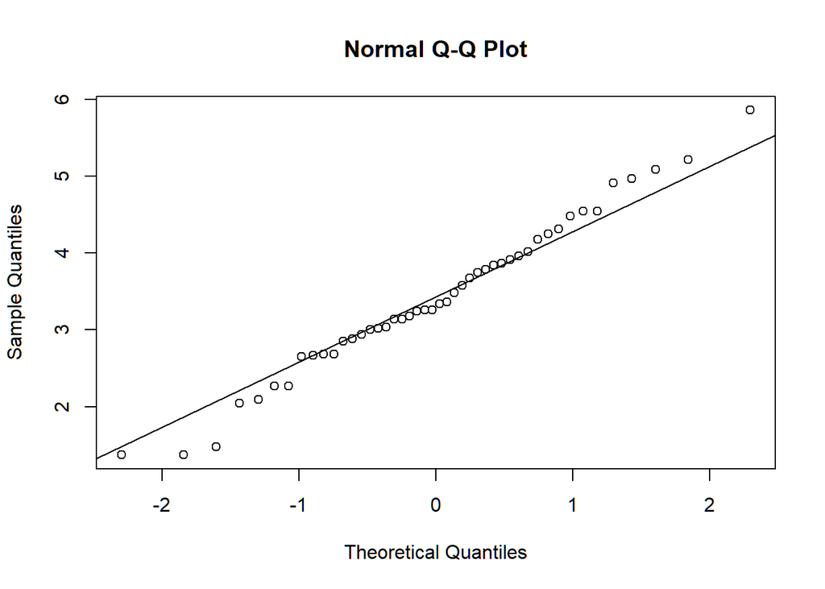

```
##
## =================
##  MISSING DATA IN in Tableau
## No missing values found in the_data.
##
##  Multiple Imputation for missing values in Tableau
## [1] "4 corr M sem parametro"
## [1] "corr M linha 55"
```

```
##
## --- RELIABILITY with 1 factor(s) in Tableau ---
## [1] "3 - antes make_corrM"
## [1] "corr M linha 55"
```

```
## Omega_h for 1 factor is not meaningful, just omega_t
```

```
## Alpha: 0.8673473
## G.6: 0.933637
## Omega Total: 0.8713869
##
## --- RELIABILITY with 3 factor(s) in Tableau ---
## [1] "3 - antes make_corrM"
## [1] "corr M linha 55"
## Alpha: 0.8673473
## G.6: 0.933637
## Omega Total: 0.9148827
##
## --- Individual CFA Fit for Tableau ---
##
## Model Test User Model:
##
##   Test statistic                                89.436
##   Degrees of freedom                                62
##   P-value                                        0.013
##
## User Model versus Baseline Model:
##
##   Comparative Fit Index (CFI)                    0.836
##
## Root Mean Square Error of Approximation:
##
##   RMSEA                                          0.098
##
## DETAILS
## =================
##                                Tst_-T
## npar                           42.000
## fmin                            0.972
## chisq                          89.436
## df                             62.000
## pvalue                          0.013
## baseline.chisq                245.069
## baseline.df                    78.000
## baseline.pvalue                 0.000
## cfi                             0.836
## tli                             0.793
```

[output cut: 41 more lines]

```
## agfi                            0.991
## pgfi                            0.593
## mfi                             0.742
## ecvi                            3.770
##
## ==========================================
##  Processing stimulus: JMP
## ==========================================
##
## =================
##  NORMALITY in JMP
##
##  #### Shapiro in JMP
##
##  #### Multivariate normality in JMP
```

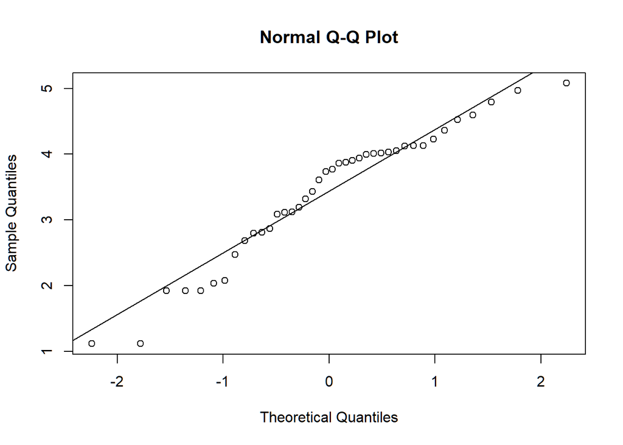

```
##
## =================
##  MISSING DATA IN in JMP
## #### Little's test for MCAR
##  Little's MCAR Test
##
##    n nIncomp nPattern  chi2 df     p
##   41       1        2 23.15 12 0.026
##
## #### Amount of missing data
## 0.187617260787992 % of data is missing
```

```
##
## --- RELIABILITY with 1 factor(s) in JMP ---
## [1] "3 - antes make_corrM"
## [1] "corr M linha 55"
```

```
## Omega_h for 1 factor is not meaningful, just omega_t
```

```
## Alpha: 0.9149629
## G.6: 0.9775661
## Omega Total: 0.9168351
##
## --- RELIABILITY with 3 factor(s) in JMP ---
## [1] "3 - antes make_corrM"
## [1] "corr M linha 55"
```

```
## Alpha: 0.9149629
## G.6: 0.9775661
## Omega Total: 0.9542081
##
## --- Individual CFA Fit for JMP ---
```

```
##
## Model Test User Model:
##
##   Test statistic                               137.136
##   Degrees of freedom                                62
##   P-value                                        0.000
##
## User Model versus Baseline Model:
##
##   Comparative Fit Index (CFI)                    0.701
##
## Root Mean Square Error of Approximation:
##
##   RMSEA                                          0.172
##
## DETAILS
## =================
##                                T_-JMP
## npar                           42.000
## fmin                            1.672
## chisq                         137.136
## df                             62.000
## pvalue                          0.000
## baseline.chisq                328.985
## baseline.df                    78.000
## baseline.pvalue                 0.000
## cfi                             0.701
## tli                             0.623
## cfi.robust                      0.705
## tli.robust                      0.628
## nnfi                            0.623
## rfi                             0.476
## nfi                             0.583
## pnfi                            0.464
## ifi                             0.719
## rni                             0.701
## nnfi.robust                     0.628
## rni.robust                      0.705
## logl                         -568.333
## unrestricted.logl            -499.765
```

[output cut: 29 more lines]

```
## agfi                            0.980
## pgfi                            0.589
## mfi                             0.400
## ecvi                            5.394
##
## ==========================================
##  Processing stimulus: Excel
## ==========================================
##
## =================
##  NORMALITY in Excel
##
##  #### Shapiro in Excel
##
##  #### Multivariate normality in Excel
```

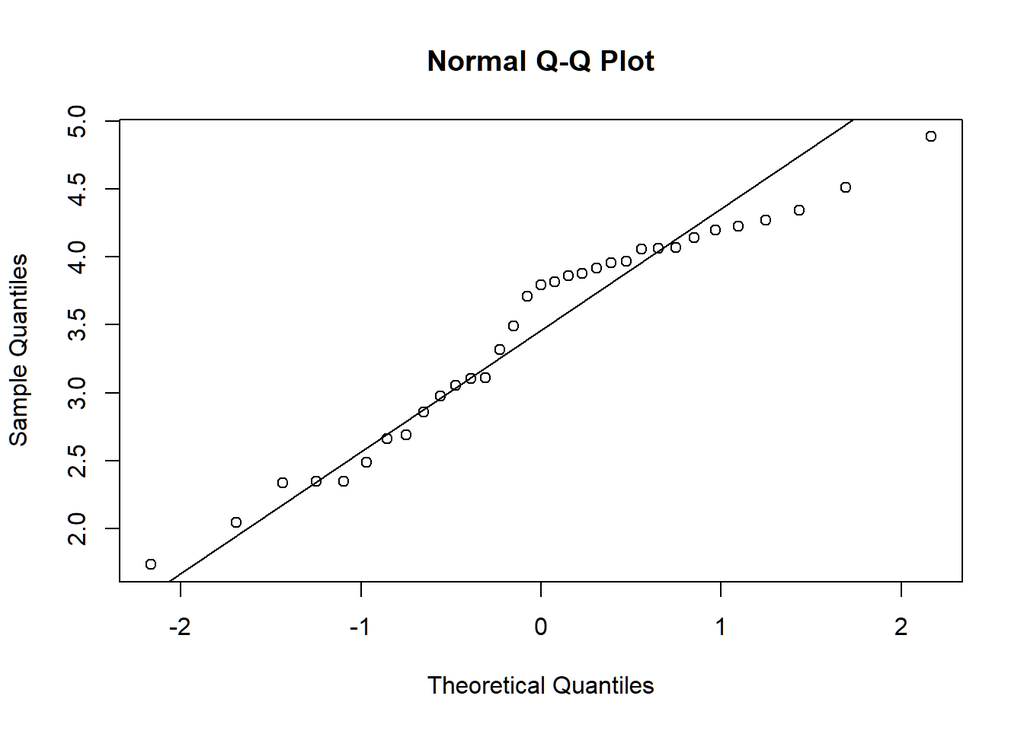

```
##
## =================
##  MISSING DATA IN in Excel
## #### Little's test for MCAR
##  Little's MCAR Test
##
##    n nIncomp nPattern  chi2 df     p
##   34       1        2 12.31 12 0.421
##
## #### Amount of missing data
## 0.226244343891403 % of data is missing
```

```
##
## --- RELIABILITY with 1 factor(s) in Excel ---
## [1] "3 - antes make_corrM"
## [1] "corr M linha 55"
```

```
## Omega_h for 1 factor is not meaningful, just omega_t
```

```
## Alpha: 0.9130716
## G.6: 0.9834554
## Omega Total: 0.9149981
##
## --- RELIABILITY with 3 factor(s) in Excel ---
## [1] "3 - antes make_corrM"
## [1] "corr M linha 55"
```

```
## Alpha: 0.9130716
## G.6: 0.9834554
## Omega Total: 0.9412448
##
## --- Individual CFA Fit for Excel ---
##
## Model Test User Model:
##
##   Test statistic                                92.119
##   Degrees of freedom                                62
##   P-value                                        0.008
##
## User Model versus Baseline Model:
##
##   Comparative Fit Index (CFI)                    0.832
##
## Root Mean Square Error of Approximation:
##
##   RMSEA                                          0.120
##
## DETAILS
## =================
##                                Tst_-E
## npar                           42.000
## fmin                            1.355
## chisq                          92.119
## df                             62.000
## pvalue                          0.008
## baseline.chisq                256.981
## baseline.df                    78.000
## baseline.pvalue                 0.000
## cfi                             0.832
## tli                             0.788
## cfi.robust                      0.827
## tli.robust                      0.783
## nnfi                            0.788
## rfi                             0.549
## nfi                             0.642
## pnfi                            0.510
## ifi                             0.846
```

[output cut: 34 more lines]

```
## agfi                            0.984
## pgfi                            0.591
## mfi                             0.642
## ecvi                            5.180
##
## ==========================================
##  Processing stimulus: Data Studio
## ==========================================
##
## =================
##  NORMALITY in Data Studio
##
##  #### Shapiro in Data Studio
##
##  #### Multivariate normality in Data Studio
```

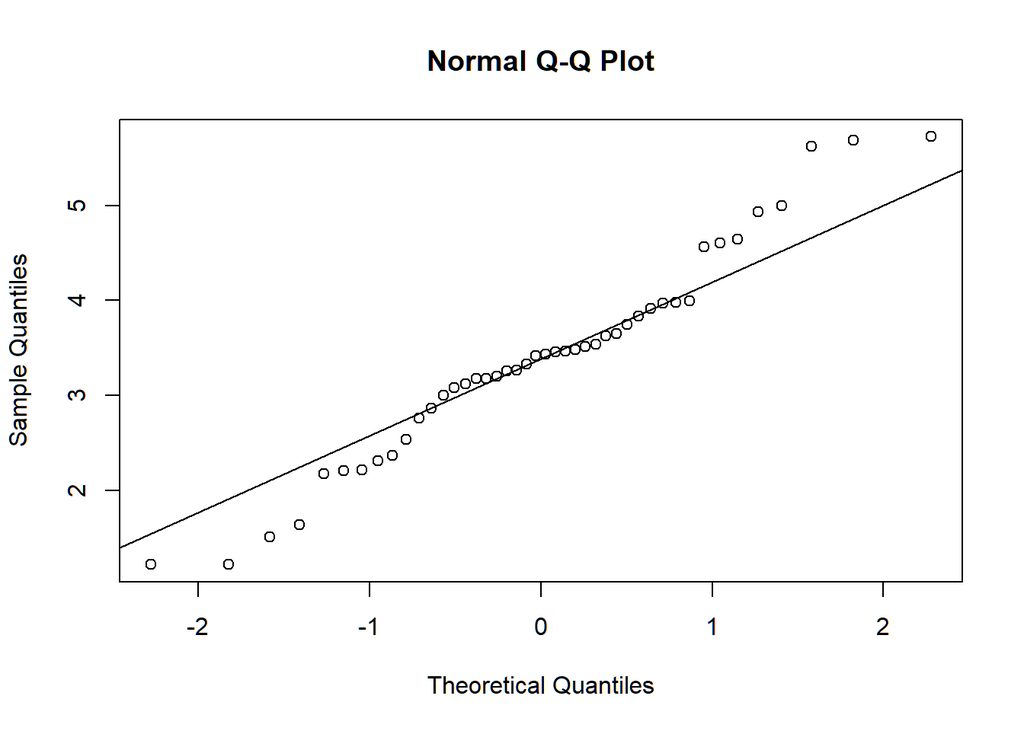

```
##
## =================
##  MISSING DATA IN in Data Studio
## No missing values found in the_data.
##
##  Multiple Imputation for missing values in Data Studio
## [1] "4 corr M sem parametro"
## [1] "corr M linha 55"
```

```
##
## --- RELIABILITY with 1 factor(s) in Data Studio ---
## [1] "3 - antes make_corrM"
## [1] "corr M linha 55"
```

```
## Omega_h for 1 factor is not meaningful, just omega_t
```

```
## Alpha: 0.9246009
## G.6: 0.9491362
## Omega Total: 0.9257615
##
## --- RELIABILITY with 3 factor(s) in Data Studio ---
## [1] "3 - antes make_corrM"
## [1] "corr M linha 55"
```

```
## Alpha: 0.9246009
## G.6: 0.9491362
## Omega Total: 0.955402
##
## --- Individual CFA Fit for Data Studio ---
```

```
##
## Model Test User Model:
##
##   Test statistic                               114.795
##   Degrees of freedom                                62
##   P-value                                        0.000
##
## User Model versus Baseline Model:
##
##   Comparative Fit Index (CFI)                    0.819
##
## Root Mean Square Error of Approximation:
##
##   RMSEA                                          0.139
##
## DETAILS
## =================
##                                Ts_-DS
## npar                           42.000
## fmin                            1.304
## chisq                         114.795
## df                             62.000
## pvalue                          0.000
## baseline.chisq                369.512
## baseline.df                    78.000
## baseline.pvalue                 0.000
## cfi                             0.819
## tli                             0.772
## cfi.robust                      0.819
## tli.robust                      0.772
## nnfi                            0.772
## rfi                             0.609
## nfi                             0.689
## pnfi                            0.548
## ifi                             0.828
## rni                             0.819
## nnfi.robust                     0.772
## rni.robust                      0.819
## logl                         -561.221
## unrestricted.logl            -503.823
```

[output cut: 29 more lines]

```
## agfi                            0.980
## pgfi                            0.589
## mfi                             0.549
## ecvi                            4.518
##
## ==========================================
##  Processing stimulus: Power BI
## ==========================================
##
## =================
##  NORMALITY in Power BI
##
##  #### Shapiro in Power BI
##
##  #### Multivariate normality in Power BI
```

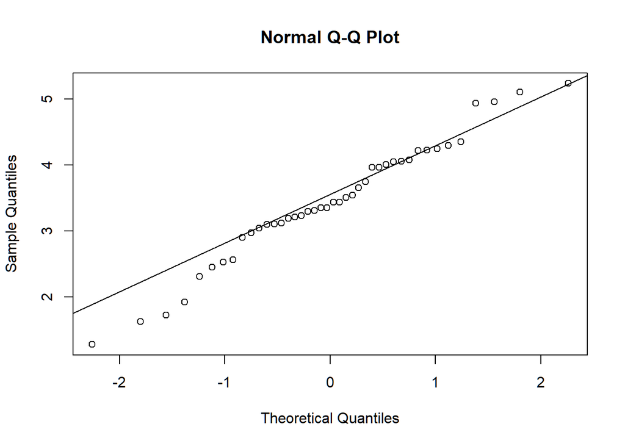

```
##
## =================
##  MISSING DATA IN in Power BI
## #### Little's test for MCAR
##  Little's MCAR Test
##
##    n nIncomp nPattern  chi2 df     p
##   44       2        3 34.12 24 0.083
##
## #### Amount of missing data
## 0.34965034965035 % of data is missing
```

```
##
## --- RELIABILITY with 1 factor(s) in Power BI ---
## [1] "3 - antes make_corrM"
## [1] "corr M linha 55"
```

```
## Omega_h for 1 factor is not meaningful, just omega_t
```

```
## Alpha: 0.9128499
## G.6: 0.9742092
## Omega Total: 0.9140439
##
## --- RELIABILITY with 3 factor(s) in Power BI ---
## [1] "3 - antes make_corrM"
## [1] "corr M linha 55"
```

```
## Alpha: 0.9128499
## G.6: 0.9742092
## Omega Total: 0.9463409
##
## --- Individual CFA Fit for Power BI ---
##
## Model Test User Model:
##
##   Test statistic                                74.599
##   Degrees of freedom                                62
##   P-value                                        0.131
##
## User Model versus Baseline Model:
##
##   Comparative Fit Index (CFI)                    0.952
##
## Root Mean Square Error of Approximation:
##
##   RMSEA                                          0.068
##
## DETAILS
## =================
##                                T_-PBI
## npar                           42.000
## fmin                            0.848
## chisq                          74.599
## df                             62.000
## pvalue                          0.131
## baseline.chisq                342.725
## baseline.df                    78.000
## baseline.pvalue                 0.000
## cfi                             0.952
## tli                             0.940
## cfi.robust                      0.949
## tli.robust                      0.936
## nnfi                            0.940
## rfi                             0.726
## nfi                             0.782
## pnfi                            0.622
## ifi                             0.955
```

[output cut: 23 more lines]

```
## rmr_nomean                      0.074
## srmr                            0.083
## srmr_bentler                    0.083
## srmr_bentler_nomean             0.088
## crmr                            0.088
## crmr_nomean                     0.095
## srmr_mplus                      0.086
## srmr_mplus_nomean               0.088
## cn_05                          49.000
## cn_01                          54.557
## gfi                             0.994
## agfi                            0.989
## pgfi                            0.592
## mfi                             0.867
## ecvi                            3.605
```

```r
row_names <- c("alpha", "omega.tot (1 factor)", "omega.tot (3 factors)")
reliab_df <- data.frame(row.names = row_names)

nbs_factors <- c(1, 3)

for (letter in stimuli_letters) {
  cat(paste("\n=========================================="))
  cat(paste("\n Processing stimulus:", letter))
  cat(paste("\n==========================================\n"))

  the_data <- grp_data %>%
    dplyr::filter(stimulus == letter) %>%
    droplevels()

  if (nrow(the_data) == 0) {
    message("Sem dados para o estímulo: ", letter)
    next
  }

  # Selecionar variáveis de interesse
  subset_data <- select_all_variables(the_data, columns_to_keep)

  # 1. Executar checagens de normalidade e adequação protegidas
  tryCatch({
    stimulus_data_test(subset_data, letter)
  }, error = function(e) {
    message("Aviso nos testes preliminares para ", letter, ": ", e$message)
  })

  # 2. Confiabilidade por número de fatores
  this_alpha <- NA_real_
  this_om_1f <- NA_real_
  this_om_4f <- NA_real_

  for (nb_f in nbs_factors) {
    cat(paste("\n--- RELIABILITY with", nb_f, "factor(s) in", letter, "---\n"))

    tryCatch({

         print("3 - antes make_corrM")

      colnames(subset_data)

      c_mat <- make_corrM(subset_data)

      if (!is.null(c_mat) && ncol(c_mat) >= 2) {
        # Suavização para matrizes não positivas definidas em subamostras
        if (any(eigen(c_mat)$values <= 0)) {
          c_mat <- psych::cor.smooth(c_mat)
        }

        om <- suppressWarnings(
          psych::omega(
            c_mat,
            nfactors = nb_f,
            n.obs    = nrow(subset_data),
            rotate   = "Promax",
            plot     = FALSE
          )
        )

        cat("Alpha:", om$alpha, "\n")
        cat("G.6:", om$G6, "\n")
        cat("Omega Total:", om$omega.tot, "\n")

        if (nb_f == 1) {
          this_alpha <- om$alpha
          this_om_1f <- om$omega.tot
        } else {
          this_om_4f <- om$omega.tot
        }
      }
    }, error = function(e) {
      message("Erro ao calcular Omega (", nb_f, " fatores) em ", letter, ": ", e$message)
    })
  }

  # Armazenar resultados de confiabilidade da coluna
  reliab_df[[paste(letter, "- factors")]] <- c(this_alpha, this_om_1f, this_om_4f)

  # 3. CFA individual por estímulo
  cat(paste("\n--- Individual CFA Fit for", letter, "---\n"))
  tryCatch({
    this_fit <- lavaan::cfa(
      model   = model_string,
      data    = the_data,
      missing = "fiml"
    )

    this_filename <- paste0(this_model, '-', letter)
    fitMeasures_output(this_fit, this_filename)
  }, error = function(e) {
    message("Erro na CFA para o estímulo ", letter, ": ", e$message)
  })
}
```

```r
# Salvar tabela de confiabilidade por estímulo
write.csv(reliab_df, file.path(output_dir, "generatedData-CFA/reliability-global-by-stimuli.csv"))
```

```r
# Bifactor / Hierarchical Model: 1 General Factor (overall_UX) + Specific Subfactors

# 1. Define the general latent factor syntax (valid identifier without spaces)
overall_items <- paste(unlist(UX_factors), collapse = " + ")
overall_factor_string <- paste0("overall_UX =~ ", overall_items)

# 2. Define specific factor syntax for each subscale
factor_strings <- sapply(names(UX_factors), function(factor_name) {
  paste0(factor_name, " =~ ", paste(unlist(UX_factors[[factor_name]]), collapse = " + "))
})

# 3. Combine factor syntax into a unified lavaan model specification
global_model_string <- paste(c(overall_factor_string, factor_strings), collapse = "\n")

cat("--- Bifactor Model Specification ---\n")
cat(global_model_string, "\n\n")

# 4. Filter dataset to include only valid stimulus groups and drop unused levels
grp_data_cfa <- grp_data %>%
  dplyr::filter(stimulus %in% stimuli_letters) %>%
  droplevels()

# 5. Fit the CFA model on pooled data across selected stimuli
# orthogonal = TRUE ensures general and specific factors are uncorrelated (standard bifactor assumption)
global_fit <- lavaan::cfa(
  model      = global_model_string,
  data       = grp_data_cfa,
  missing    = "fiml",
  orthogonal = TRUE
)

# Display model summary with standardized loadings and fit measures
summary(global_fit, fit.measures = TRUE, standardized = TRUE)

# 6. Estimate McDonald's Omega coefficients from the SEM object
cat("\n--- Omega from SEM Results ---\n")
om_sem <- psych::omegaFromSem(
  global_fit,
  flip = TRUE,
  plot = TRUE
)

print(om_sem)
```

[output not shown]